# EDA

```python
# Importing the libraries
import numpy as np
import matplotlib.pyplot as plt
import pandas as pd
import seaborn as sns

from IPython.display import display, display_html , HTML

pd.set_option('display.max_row',40) #Affiche au plus 40 éléments dans les résultats de pandas
pd.set_option('display.max_column',40) #Affiche au plus 40 éléments dans les résultats de pandas

# Comment this if the data visualisations doesn't work on your side
%matplotlib inline
plt.style.use('bmh')

import warnings
warnings.filterwarnings('ignore')
```

[figure not shown]

## Objectif(s) :

- Comprendre les données du serveur météonet individuellement
- Comprendre le lien entre les différentes données, ainsi que les corrélations entre les différents modèles de MeteoFrance (Arome et Arpege)

## Features

Base

Arome

Arpege

| Name | Description | Unit |
| --- | --- | --- |
| dd | Wind direction | degrees (°) |
| ff | Wind speed | m.s<sup>-1</sup> |
| precip | Precipitation during the reporting period | kg.m<sup>2</sup> |
| hu | Humidity | percentage(%) |
| td | Dew point | Kelvin (K) |
| t | Temperature | Kelvin (K) |
| psl | Pressure reduced to sea level | Pascal (Pa) |
| lat | Latitude | ° N |
| lon | Longitude | ° E |
| height_sta | Station height | Metres (m) |

| Name | Description | Unit |
| --- | --- | --- |
| w | Wind speed | m.s<sup>-1</sup> |
| p3031 | Wind direction | degrees (°) |
| u10 | 10m U wind component | m.s<sup>-1</sup> |
| v10 | 10m V wind component | m.s<sup>-1</sup> |
| t2m | Temperature (at 2m) | Kelvin (K) |
| d2m | Dew point (at 2m) | Kelvin (K) |
| r | Humidity | Percentage (%) |
| msl | Ground Pressure (P0) | Pascal (Pa) |

| Name | Description | Unit |
| --- | --- | --- |
| w_3D_arpege | Wind speed | m.s<sup>-1</sup> |
| p3031_3D_arpege | Wind direction | degrees (°) |
| u_3D_arpege | 10m U wind component | m.s<sup>-1</sup> |
| v_3D_arpege | 10m V wind component | m.s<sup>-1</sup> |
| w_3D_arpege | Vertical velocity | Pascal.s<sup>-1</sup> |
| z_3D_arpege | Geopotential | m.s<sup>-2</sup> |
| t_3D_arpege | Temperature | Kelvin (K) |
| p3014_3D_arpege | Pseudo-adiabatic potential temperature | Kelvin (K) |
| r_3D_arpege | Relative humidity | Percentage (%) |

[figure not shown]

# Observations on station n° 14066001

```python
trainset = pd.read_csv("Dataset/dataapp.csv")
testset = pd.read_csv("Dataset/datatest.csv")
display(HTML('<h1>Trainset</h1>'))
display(trainset.head())
print("The trainset shapes are :",trainset.shape)
print("The trainset types are :",trainset.dtypes.value_counts())
display(HTML('<h1>Testset</h1>'))
display(testset.head())
print("The testset shapes are :",testset.shape)
print("The testset types are :",testset.dtypes.value_counts())
```

Trainset

|  | Id | dd | hu | td | t | ff | precip | month | number_sta | Ground_truth | ws | p3031 | u10 | v10 | t2m | d2m | r | msl | t_3D_arpege | p3014_3D_arpege | r_3D_arpege | ws_3D_arpege | p3031_3D_arpege | u_3D_arpege | v_3D_arpege | w_3D_arpege | z_3D_arpege | lat | lon | … |
| --- | --- | --- | --- | --- | --- | --- | --- | --- | --- | --- | --- | --- | --- | --- | --- | --- | --- | --- | --- | --- | --- | --- | --- | --- | --- | --- | --- | --- | --- | --- |
| 0 | 14066001_158 | 300.916667 | 90.050000 | 286.600417 | 288.247083 | 2.550000 | 0.2 | 6 | 14066001 | 0.0 | 3.455806 | 307.139567 | 2.638302 | -1.791395 | 285.563700 | 285.411133 | 99.007853 | 102340.333333 | 288.659065 | 286.655331 | 81.400434 | 4.389184 | 303.345674 | 2.590675 | -3.387308 | -0.074158 | 1877.207950 | 49.334 | -0.431 | … |
| 1 | 14066001_413 | 156.916667 | 92.275000 | 277.223750 | 278.399167 | 1.950000 | 0.2 | 2 | 14066001 | 0.2 | 2.484051 | 210.949178 | 0.872938 | 0.287528 | 280.451660 | 279.481303 | 93.651062 | 103153.229167 | 281.563477 | 277.957520 | 58.476706 | 7.302530 | 175.057158 | -0.380868 | 7.127424 | 0.142664 | 2044.011949 | 49.334 | -0.431 | … |
| 2 | 14066001_207 | 240.958333 | 77.779167 | 285.496250 | 289.606667 | 2.724583 | 0.2 | 7 | 14066001 | 0.0 | 3.394090 | 255.705485 | 2.150585 | -0.762113 | 289.637329 | 286.834880 | 83.764750 | 102279.541667 | 288.085248 | 286.556009 | 84.959135 | 4.850707 | 290.563161 | 4.265345 | -1.478121 | -0.046789 | 1890.304917 | 49.334 | -0.431 | … |
| 3 | 14066001_503 | 308.750000 | 92.241667 | 282.962083 | 284.201667 | 4.929167 | 11.1 | 5 | 14066001 | 3.2 | 3.959870 | 225.794413 | 1.918382 | -1.448843 | 287.879557 | 286.346598 | 90.680155 | 101674.895833 | 283.323845 | 281.470990 | 79.345560 | 6.313782 | 253.830480 | 5.942706 | 1.900143 | 0.059754 | 1138.972541 | 49.334 | -0.431 | … |
| 4 | 14066001_175 | 243.791667 | 82.520833 | 286.026250 | 289.084167 | 2.829167 | 0.0 | 6 | 14066001 | 0.8 | 3.277412 | 191.829834 | 1.609237 | -0.285060 | 288.259969 | 286.254354 | 87.888194 | 101986.666667 | 287.503619 | 285.956342 | 84.257568 | 4.353418 | 280.565602 | 3.957619 | -1.017305 | -0.031922 | 1670.239890 | 49.334 | -0.431 | … |

```
The trainset shapes are : (543, 30)
The trainset types are : float64    27
int64       2
object      1
dtype: int64
```

Testset

|  | Id | dd | hu | td | t | ff | precip | month | number_sta | Ground_truth | ws | p3031 | u10 | v10 | t2m | d2m | r | msl | t_3D_arpege | p3014_3D_arpege | r_3D_arpege | ws_3D_arpege | p3031_3D_arpege | u_3D_arpege | v_3D_arpege | w_3D_arpege | z_3D_arpege | lat | lon | … |
| --- | --- | --- | --- | --- | --- | --- | --- | --- | --- | --- | --- | --- | --- | --- | --- | --- | --- | --- | --- | --- | --- | --- | --- | --- | --- | --- | --- | --- | --- | --- |
| 0 | 14066001_218 | 184.458333 | 81.370833 | 286.353333 | 289.682917 | 2.901250 | 0.2 | 8 | 14066001 | 0.0 | 3.541646 | 217.081543 | 2.108142 | 0.017531 | 289.806946 | 287.057983 | 84.149022 | 102854.937500 | 288.726620 | 286.964499 | 83.644000 | 6.072985 | 283.392923 | 5.720017 | -0.826134 | -0.005124 | 2320.597426 | 49.334 | -0.431 | … |
| 1 | 14066001_104 | 174.583333 | 84.291667 | 280.944583 | 283.611250 | 3.090833 | 9.1 | 4 | 14066001 | 0.6 | 4.325819 | 168.072886 | -0.767979 | 3.379661 | 283.829000 | 281.196452 | 83.987106 | 100922.062500 | 282.888184 | 281.173369 | 80.486809 | 5.406487 | 186.869141 | 0.753966 | 4.740736 | 0.151035 | 830.048024 | 49.334 | -0.431 | … |
| 2 | 14066001_161 | 114.166667 | 88.708333 | 287.568750 | 289.509583 | 2.067917 | 0.0 | 6 | 14066001 | 2.2 | 2.759081 | 131.481934 | -1.665173 | -0.338657 | 288.331116 | 286.670410 | 90.094584 | 101243.458333 | 290.259507 | 287.424345 | 74.096536 | 4.653700 | 144.099092 | -3.089391 | 1.827841 | 0.043548 | 1058.046530 | 49.334 | -0.431 | … |
| 3 | 14066001_1 | 205.625000 | 82.300000 | 279.997500 | 282.936667 | 8.041250 | 3.4 | 1 | 14066001 | 11.7 | 10.600895 | 212.232279 | 5.115749 | 7.128517 | 283.412374 | 279.927063 | 79.110545 | 100319.489583 | 283.509076 | 281.798254 | 82.191787 | 11.340173 | 198.634464 | 3.425157 | 9.258523 | 0.359990 | 173.634967 | 49.334 | -0.431 | … |
| 4 | 14066001_550 | 100.291667 | 83.654167 | 287.027500 | 289.923750 | 2.681667 | 0.2 | 7 | 14066001 | 0.0 | 4.778276 | 269.489054 | 4.044821 | -0.534096 | 289.456462 | 286.929525 | 85.368632 | 102331.916667 | 290.694767 | 288.078384 | 77.382748 | 5.298101 | 57.625890 | -4.129518 | -2.779003 | -0.102924 | 1440.047220 | 49.334 | -0.431 | … |

```
The testset shapes are : (181, 30)
The testset types are : float64    27
int64       2
object      1
dtype: int64
```

## Comparaison des distributions

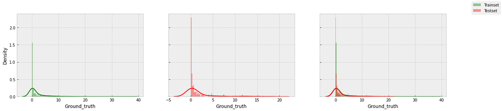

```python
fig, ax = plt.subplots(1,3,sharey=True,figsize=(20,4))
sns.distplot(trainset['Ground_truth'], color='g', bins=100, hist_kws={'alpha': 0.4}, ax=ax[0], label='Trainset');
sns.distplot(testset['Ground_truth'], color='r', bins=100, hist_kws={'alpha': 0.4}, ax=ax[1], label='Testset');
sns.distplot(trainset['Ground_truth'], color='g', bins=100, hist_kws={'alpha': 0.4}, ax=ax[2]);
sns.distplot(testset['Ground_truth'], color='r', bins=100, hist_kws={'alpha': 0.4}, ax=ax[2]);
fig.legend()
plt.show()
```

```python
trainset_description = pd.DataFrame(trainset['Ground_truth'].describe())
testset_description = pd.DataFrame(testset['Ground_truth'].describe())
trainset_description_styler = trainset_description.style.set_table_attributes("style='display:inline'").set_caption('Trainset').set_table_styles([{
    'selector': 'caption',
    'props': [
        ('color', '#585858'),
        ('font-size', '30px')
    ]
}])
testset_description_styler = testset_description.style.set_table_attributes("style='display:inline'").set_caption('Testset').set_table_styles([{
    'selector': 'caption',
    'props': [
        ('color', '#585858'),
        ('font-size', '30px')
    ]
}])
space = "\xa0" * 50
display_html(trainset_description_styler._repr_html_() + space + testset_description_styler._repr_html_(), raw=True)
```

Trainset

|  | Ground_truth |
| --- | --- |
| count | 543.000000 |
| mean | 1.994843 |
| std | 4.102849 |
| min | 0.000000 |
| 25% | 0.000000 |
| 50% | 0.200000 |
| 75% | 2.200000 |
| max | 36.100000 |

Testset

|  | Ground_truth |
| --- | --- |
| count | 181.000000 |
| mean | 1.756354 |
| std | 3.532488 |
| min | 0.000000 |
| 25% | 0.000000 |
| 50% | 0.200000 |
| 75% | 1.600000 |
| max | 18.400000 |

## Commentaires

Les distributions sont globalement similaires. Les moyennes correspondent et les écart-types sont très proches également. La grosse différence réside dans les valeurs extrêmes / outliers qui sont beaucoup plus élevées et nombreuses dans le trainset que dans le testset

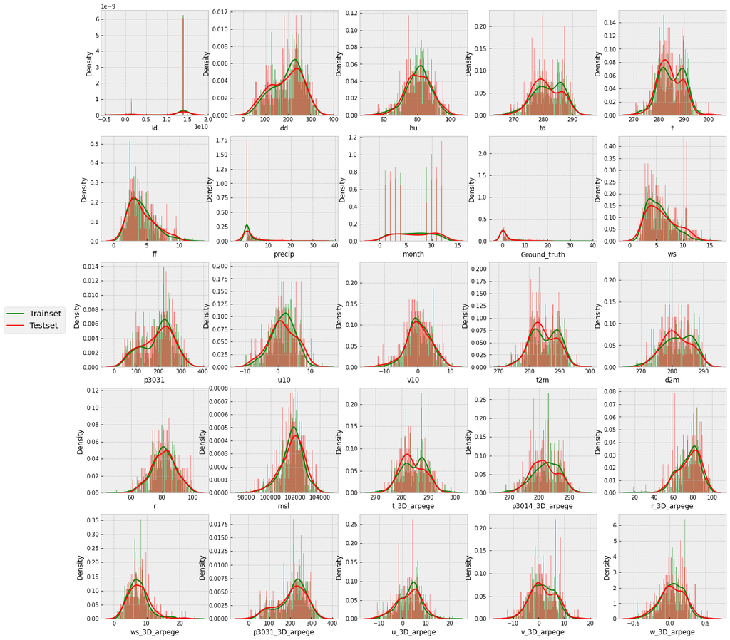

```python
nb_lignes = 5
nb_colonnes = 5

données_stations = ["lat","lon","height_sta","number_sta"]
for data in données_stations:
    if data in trainset.columns:
        trainset = trainset.drop(data,axis=1)
    if data in testset.columns:
        testset = testset.drop(data,axis=1)

fig, ax = plt.subplots(nb_lignes,nb_colonnes,figsize=(20,20))
for i in range(nb_lignes):
    for j in range(nb_colonnes):
        sns.distplot(trainset[trainset.columns[nb_lignes*i+j]], color='g', bins=100, hist_kws={'alpha': 0.4}, ax=ax[i][j]);
        sns.distplot(testset[testset.columns[nb_lignes*i+j]], color='r', bins=100, hist_kws={'alpha': 0.4}, ax=ax[i][j]);
fig.legend(["Trainset","Testset"],loc='center left',fontsize='x-large')
plt.show()
```

# Base Checklist

## Features Analysis :

- **Target Analysis** :
  - Balanced (Y/N) : NO -> Skewed arround 0

## Mid-Conclusion

**We can drop the columns that have no variance (i.e): number_sta, height_sta, lat, lon**

**We can keep the "Id" column for later so we can have the time dimension ("Id" feature are sorted chronologicaly)**

# Correlations on features

```python
trainset_corr = trainset.corr()['Ground_truth'][:-1] # -1 because the latest row is SalePrice
golden_features_list = trainset_corr[abs(trainset_corr) > 0.17].sort_values(ascending=False)
del golden_features_list['Ground_truth']
print("There are {} strongly correlated values with Ground_truth in trainset:\n{}".format(len(golden_features_list), golden_features_list))
print("--------")
testset_corr = testset.corr()['Ground_truth'][:-1] # -1 because the latest row is SalePrice
golden_features_list = testset_corr[abs(testset_corr) > 0.17].sort_values(ascending=False)
del golden_features_list['Ground_truth']
print("There are {} strongly correlated values with Ground_truth in testset:\n{}".format(len(golden_features_list), golden_features_list))
```

```
There are 7 strongly correlated values with Ground_truth in trainset:
precip          0.253079
ws              0.200266
u10             0.192514
ws_3D_arpege    0.179662
ff              0.177599
u_3D_arpege     0.171108
msl            -0.218911
Name: Ground_truth, dtype: float64
--------
There are 2 strongly correlated values with Ground_truth in testset:
precip    0.196791
msl      -0.198063
Name: Ground_truth, dtype: float64
```

Perfect, we now have a list of strongly correlated values but this list is incomplete as we know that correlation is affected by outliers. So we could proceed as follow:

- Plot the numerical features and see which ones have very few or explainable outliers
- Remove the outliers from these features and see which one can have a good correlation without their outliers

Btw, correlation by itself does not always explain the relationship between data so ploting them could even lead us to new insights and in the same manner, check that our correlated values have a linear relationship to the Ground_truth.

For example, relationships such as curvilinear relationship cannot be guessed just by looking at the correlation value so lets take the features we excluded from our correlation table and plot them to see if they show some kind of pattern.

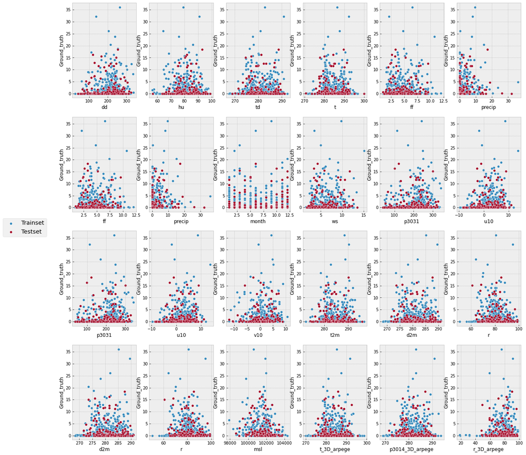

```python
nb_lignes = 4
nb_colonnes = 6

fig, ax = plt.subplots(nb_lignes,nb_colonnes,figsize=(20,20))
for i in range(nb_lignes):
    for j in range(nb_colonnes):
        sns.scatterplot(data=trainset,x=trainset.columns.drop(["Id","Ground_truth"])[nb_lignes*i+j],y='Ground_truth', ax=ax[i][j]);
        sns.scatterplot(data=testset,x=testset.columns.drop(["Id","Ground_truth"])[nb_lignes*i+j],y='Ground_truth', ax=ax[i][j]);
fig.legend(["Trainset","Testset"],loc='center left',fontsize='x-large')
plt.show()
```

## Commentaires

We can't clearly identify relationships using these graphs. Most of them seems to have a normal relationship with the Ground_truth.

However, we can see that some features seems correlated : t, td, t2m, d2m, t_3D_arpege, p3014_3D_arpege

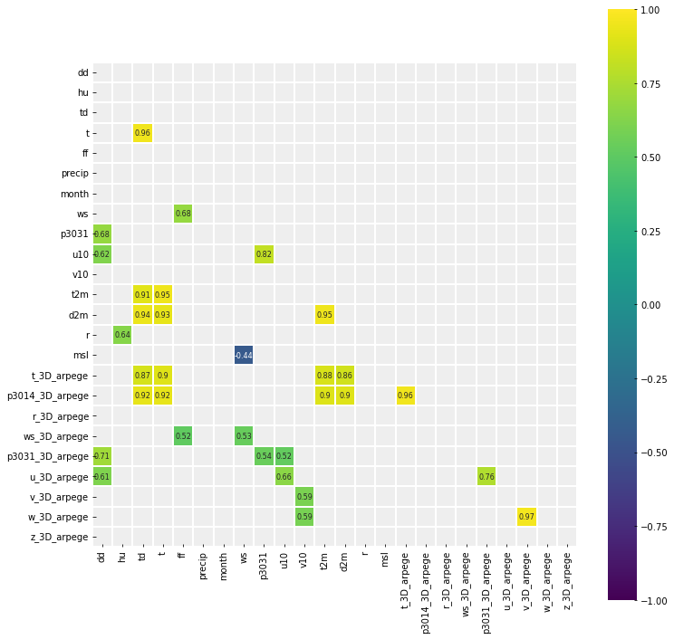

```python
corr = trainset.drop('Ground_truth', axis=1).corr() # We already examined SalePrice correlations
matrix = np.triu(corr)
# corr = np.triu(corr)
plt.figure(figsize=(12, 12))
sns.heatmap(corr[(corr >= 0.5) | (corr <= -0.4)],
            cmap='viridis', vmax=1.0, vmin=-1.0, linewidths=0.1,
            annot=True, annot_kws={"size": 8}, square=True, mask=matrix);
```

# Outliers analysis

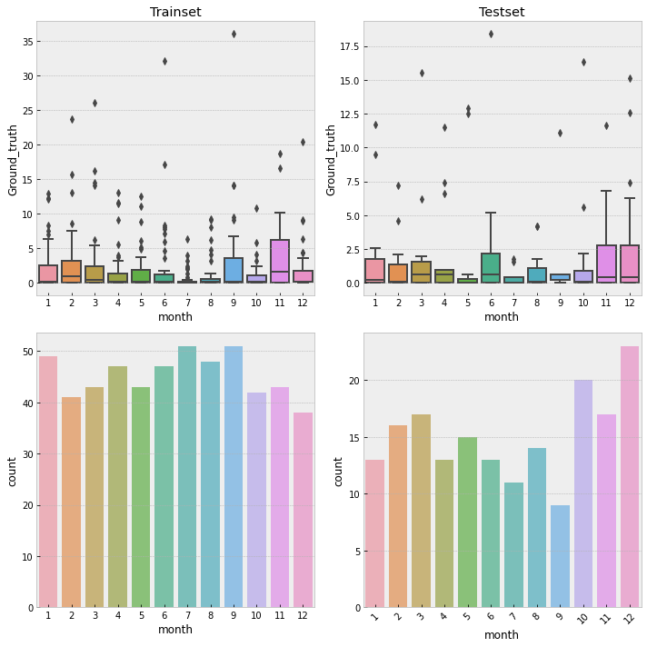

```python
fig, axs = plt.subplots(nrows=2,ncols=2,figsize = (10, 10));
sns.boxplot(x='month', y='Ground_truth', data=trainset, ax=axs[0][0]).set_title('Trainset');
sns.countplot(x="month", alpha=0.7, data=trainset, ax=axs[1][0]);
sns.boxplot(x='month', y='Ground_truth', data=testset, ax=axs[0][1]).set_title('Testset');
sns.countplot(x="month", alpha=0.7, data=testset, ax=axs[1][1]);
plt.xticks(rotation=45);
plt.tight_layout()
```

## Commentaires

On retrouve une proportion d'outliers raisonnable compte tenu du nombre d'observations par mois. Peu de variation entre trainset et testset

## PCA

```python
from sklearn.decomposition import PCA
from sklearn.pipeline import make_pipeline
from sklearn.preprocessing import scale

X_train = pd.DataFrame(scale(trainset.drop(["Ground_truth","Id"],axis=1)),columns=trainset.drop(["Ground_truth","Id"],axis=1).columns)
display(X_train.head())
y_train = trainset["Ground_truth"]

pca = PCA()
PCA_df = pd.DataFrame(pca.fit_transform(X_train))
PCA_df = pd.concat([PCA_df, y_train], axis=1)
display(PCA_df.head())
```

|  | dd | hu | td | t | ff | precip | month | ws | p3031 | u10 | v10 | t2m | d2m | r | msl | t_3D_arpege | p3014_3D_arpege | r_3D_arpege | ws_3D_arpege | p3031_3D_arpege | u_3D_arpege | v_3D_arpege | w_3D_arpege | z_3D_arpege |
| --- | --- | --- | --- | --- | --- | --- | --- | --- | --- | --- | --- | --- | --- | --- | --- | --- | --- | --- | --- | --- | --- | --- | --- | --- |
| 0 | 1.557765 | 1.274568 | 0.970158 | 0.626574 | -0.865183 | -0.431170 | -0.128483 | -0.911939 | 1.550880 | 0.266502 | -0.644580 | 0.092143 | 0.734414 | 2.274116 | 0.650313 | 0.805722 | 0.928322 | 0.509997 | -0.952609 | 1.377636 | -0.078782 | -1.093151 | -0.722676 | 0.421480 |
| 1 | -0.634332 | 1.576899 | -0.901561 | -1.351280 | -1.171995 | -0.431170 | -1.310964 | -1.327234 | 0.166860 | -0.206230 | -0.055708 | -1.013036 | -0.497377 | 1.595339 | 1.522480 | -0.631722 | -0.979987 | -1.387642 | -0.032966 | -0.539728 | -0.693868 | 1.200879 | 0.598940 | 0.638967 |
| 2 | 0.645025 | -0.392780 | 0.749750 | 0.899633 | -0.775909 | -0.431170 | 0.167137 | -0.938314 | 0.810829 | 0.135900 | -0.353027 | 0.972826 | 1.030165 | 0.342612 | 0.585089 | 0.689477 | 0.906531 | 0.804588 | -0.806922 | 1.186592 | 0.267861 | -0.676618 | -0.555851 | 0.438557 |
| 3 | 1.677011 | 1.572370 | 0.243894 | -0.185907 | 0.351411 | 2.598228 | -0.424104 | -0.696518 | 0.380458 | 0.073721 | -0.547549 | 0.592811 | 0.928736 | 1.218886 | -0.063643 | -0.275102 | -0.209128 | 0.339893 | -0.345080 | 0.637596 | 0.615062 | 0.060428 | 0.093573 | -0.541067 |
| 4 | 0.688157 | 0.251513 | 0.855546 | 0.794694 | -0.722430 | -0.486755 | -0.128483 | -0.988178 | -0.108236 | -0.009063 | -0.217898 | 0.675053 | 0.909574 | 0.865107 | 0.270860 | 0.571649 | 0.774963 | 0.746512 | -0.963899 | 1.037171 | 0.204165 | -0.576081 | -0.465228 | 0.151625 |

|  | 0 | 1 | 2 | 3 | 4 | 5 | 6 | 7 | 8 | 9 | 10 | 11 | 12 | 13 | 14 | 15 | 16 | 17 | 18 | 19 | 20 | 21 | 22 | 23 | Ground_truth |
| --- | --- | --- | --- | --- | --- | --- | --- | --- | --- | --- | --- | --- | --- | --- | --- | --- | --- | --- | --- | --- | --- | --- | --- | --- | --- |
| 0 | -2.658796 | 0.071255 | 1.645591 | -3.043251 | -0.598461 | -0.634268 | -0.498679 | -0.292279 | 0.280927 | 0.597439 | -0.234284 | 0.592209 | -0.254548 | -0.331479 | -0.398267 | -0.397567 | -0.779697 | -0.655240 | -0.307014 | 0.036780 | 0.269935 | -0.033962 | -0.010276 | 0.034102 | 0.0 |
| 1 | 2.087044 | -1.517524 | -1.848258 | -2.911243 | -0.788831 | -0.326483 | -0.230918 | -0.357062 | 0.599703 | 1.651795 | 0.144133 | -0.083296 | 0.064225 | -0.247429 | -0.272861 | -0.079778 | -0.067263 | 0.300781 | 0.307950 | -0.239632 | -0.273290 | -0.017968 | -0.028673 | 0.028619 | 0.2 |
| 2 | -2.603454 | -0.158628 | 1.194132 | -0.913620 | -1.101494 | -0.127834 | -0.456982 | 0.324227 | 0.035617 | -0.607638 | -0.041943 | -0.151343 | -0.680442 | 0.436921 | -0.045566 | -0.232139 | -0.443587 | 0.034663 | 0.090969 | -0.145044 | 0.014955 | -0.019775 | 0.003794 | -0.014478 | 0.0 |
| 3 | -1.081359 | 1.321650 | 0.648967 | -1.849730 | 1.280912 | -1.025035 | 1.068247 | 1.339100 | -0.596603 | 1.425269 | -0.049049 | -0.003741 | -0.715174 | -0.781571 | -0.665513 | -0.003333 | 0.625471 | 0.729203 | 0.164312 | -0.474181 | -0.023813 | 0.021952 | -0.019619 | 0.001207 | 3.2 |
| 4 | -2.400478 | -0.499485 | 0.731205 | -1.338135 | -0.345867 | -0.332503 | -0.665764 | 0.481014 | -0.177939 | -0.555301 | -0.352122 | 0.104076 | -0.195940 | 0.100134 | -0.222895 | -0.140122 | -0.084744 | -0.107565 | 0.203632 | 0.150513 | 0.011042 | -0.032850 | 0.011046 | -0.006430 | 0.8 |

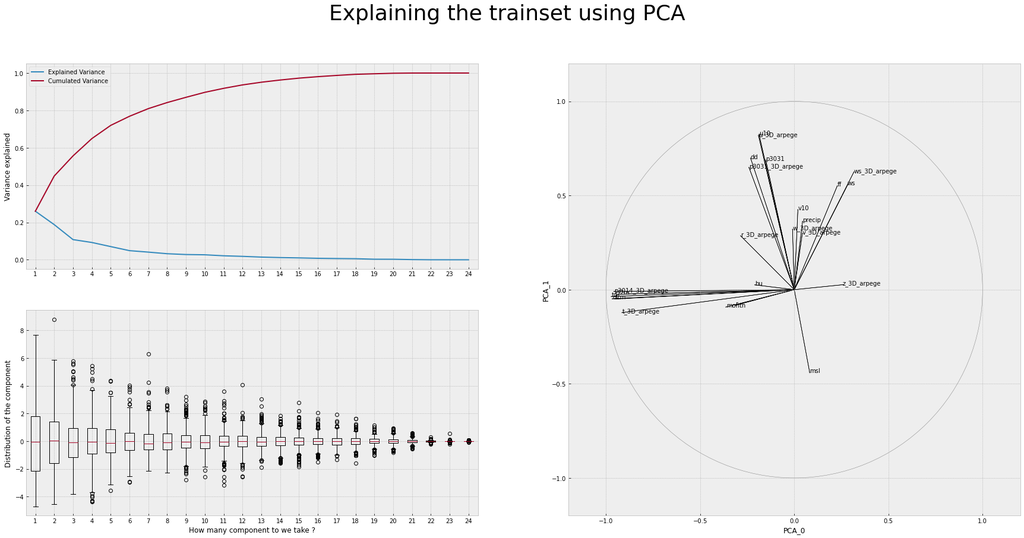

```python
fig1 = plt.figure(figsize=(30,14))
fig1.suptitle('Explaining the trainset using PCA', fontsize=36)
# fig2 = plt.figure()  # more figures are easily accessible
# fig3 = plt.figure()  # more figures are easily accessible

ax221 = fig1.add_subplot(221)  # add subplot into first position in a 2x2 grid (upper left)
ax223 = fig1.add_subplot(223, sharex=ax221)  # add to third position in 2x2 grid (lower left) and sharex with ax11
ax122 = fig1.add_subplot(122)  # add subplot to cover both upper and lower right, in a 2x2 grid. This is the same as the rightmost panel in a 1x2 grid.
## Décroissance de la variance expliquée
ax221.plot(np.arange(1,PCA_df.shape[1],1),pca.explained_variance_ratio_)
ax221.plot(np.arange(1,PCA_df.shape[1],1),pca.explained_variance_ratio_.cumsum())
ax221.legend(["Explained Variance","Cumulated Variance"])
ax221.set_ylabel('Variance explained')
## distribution des composantes principales
ax223.boxplot(PCA_df.drop("Ground_truth",axis=1))
ax223.set_xlabel('How many component to we take ?')
ax223.set_ylabel('Distribution of the component')
## coordonnées et représentation des variables
coord1=pca.components_[0]*np.sqrt(pca.explained_variance_[0])
coord2=pca.components_[1]*np.sqrt(pca.explained_variance_[1])
for i, j, nom in zip(coord1,coord2, X_train.columns):
    ax122.text(i, j, nom)
    ax122.arrow(0,0,i,j,color='black')
ax122.axis((-1.2,1.2,-1.2,1.2))
# cercle
c=plt.Circle((0,0), radius=1, color='gray', fill=False)
ax122.add_patch(c)
ax122.set_xlabel("PCA_0")
ax122.set_ylabel("PCA_1")
plt.show()
```

```python
nb_components = 24
nb_features = 24 # Unchanged
for component in range(nb_components):
    equation = ""
    for feature in range(nb_features):
        equation = equation + str(round(pca.components_[component][feature],3))+"*"+X_train.columns[feature]+" "
    print("Pour la",str(component+1),"e composante :")
    print(equation)
    print("\n")
```

```
Pour la 1 e composante :
-0.092*dd -0.083*hu -0.388*td -0.379*t 0.091*ff 0.018*precip -0.144*month 0.113*ws -0.06*p3031 -0.075*u10 0.008*v10 -0.374*t2m -0.386*d2m -0.125*r 0.033*msl -0.365*t_3D_arpege -0.382*p3014_3D_arpege -0.113*r_3D_arpege 0.126*ws_3D_arpege -0.096*p3031_3D_arpege -0.076*u_3D_arpege 0.017*v_3D_arpege -0.…


Pour la 2 e composante :
0.327*dd 0.012*hu -0.017*td -0.023*t 0.258*ff 0.169*precip -0.043*month 0.261*ws 0.323*p3031 0.387*u10 0.199*v10 -0.011*t2m -0.023*d2m -0.039*r -0.206*msl -0.057*t_3D_arpege -0.005*p3014_3D_arpege 0.134*r_3D_arpege 0.293*ws_3D_arpege 0.304*p3031_3D_arpege 0.384*u_3D_arpege 0.14*v_3D_arpege 0.15*w_3D…


Pour la 3 e composante :
0.194*dd -0.053*hu -0.006*td 0.006*t 0.181*ff 0.078*precip 0.093*month 0.083*ws 0.177*p3031 0.068*u10 -0.391*v10 0.016*t2m -0.013*d2m -0.091*r 0.036*msl -0.084*t_3D_arpege -0.048*p3014_3D_arpege 0.124*r_3D_arpege -0.128*ws_3D_arpege 0.149*p3031_3D_arpege -0.025*u_3D_arpege -0.567*v_3D_arpege -0.56*w…


Pour la 4 e composante :
-0.107*dd -0.514*hu 0.002*td 0.153*t 0.288*ff 0.013*precip 0.072*month 0.347*ws -0.112*p3031 -0.072*u10 -0.046*v10 0.174*t2m 0.018*d2m -0.468*r -0.225*msl 0.138*t_3D_arpege 0.08*p3014_3D_arpege -0.193*r_3D_arpege 0.099*ws_3D_arpege -0.186*p3031_3D_arpege -0.138*u_3D_arpege 0.029*v_3D_arpege 0.031*w_…


Pour la 5 e composante :
-0.217*dd 0.298*hu 0.083*td -0.008*t 0.197*ff 0.357*precip -0.137*month 0.225*ws -0.225*p3031 -0.095*u10 0.033*v10 -0.026*t2m 0.053*d2m 0.243*r -0.405*msl -0.108*t_3D_arpege 0.021*p3014_3D_arpege 0.454*r_3D_arpege 0.012*ws_3D_arpege -0.25*p3031_3D_arpege -0.135*u_3D_arpege -0.076*v_3D_arpege -0.049*…


Pour la 6 e composante :
-0.182*dd 0.059*hu 0.091*td 0.077*t 0.153*ff -0.061*precip 0.311*month 0.163*ws -0.206*p3031 -0.089*u10 0.029*v10 0.077*t2m 0.08*d2m 0.031*r 0.22*msl -0.013*t_3D_arpege 0.055*p3014_3D_arpege 0.085*r_3D_arpege 0.458*ws_3D_arpege -0.117*p3031_3D_arpege 0.103*u_3D_arpege -0.017*v_3D_arpege -0.054*w_3D_…


Pour la 7 e composante :
0.025*dd 0.142*hu -0.05*td -0.096*t -0.103*ff 0.55*precip 0.698*month -0.047*ws 0.102*p3031 0.065*u10 0.214*v10 0.007*t2m -0.032*d2m -0.121*r 0.054*msl -0.021*t_3D_arpege -0.07*p3014_3D_arpege -0.159*r_3D_arpege -0.129*ws_3D_arpege -0.056*p3031_3D_arpege -0.163*u_3D_arpege 0.058*v_3D_arpege -0.012*w…


Pour la 8 e composante :
0.087*dd -0.148*hu 0.008*td 0.055*t -0.124*ff 0.512*precip -0.264*month -0.268*ws -0.327*p3031 -0.313*u10 0.015*v10 0.043*t2m 0.002*d2m -0.126*r -0.233*msl 0.028*t_3D_arpege 0.026*p3014_3D_arpege -0.183*r_3D_arpege -0.0*ws_3D_arpege 0.333*p3031_3D_arpege 0.219*u_3D_arpege -0.044*v_3D_arpege -0.041*w…


Pour la 9 e composante :
-0.06*dd 0.03*hu 0.035*td 0.032*t -0.22*ff 0.004*precip -0.265*month 0.054*ws 0.302*p3031 0.32*u10 0.236*v10 0.088*t2m 0.07*d2m -0.045*r -0.351*msl 0.009*t_3D_arpege -0.009*p3014_3D_arpege -0.252*r_3D_arpege -0.156*ws_3D_arpege -0.315*p3031_3D_arpege -0.232*u_3D_arpege -0.085*v_3D_arpege -0.117*w_3D…


Pour la 10 e composante :
-0.075*dd 0.09*hu 0.03*td 0.004*t 0.298*ff 0.335*precip -0.222*month -0.036*ws 0.168*p3031 0.084*u10 -0.333*v10 -0.044*t2m 0.068*d2m 0.361*r 0.231*msl 0.183*t_3D_arpege 0.039*p3014_3D_arpege -0.503*r_3D_arpege 0.265*ws_3D_arpege -0.127*p3031_3D_arpege -0.097*u_3D_arpege 0.058*v_3D_arpege 0.01*w_3D_a…


```

[output cut: 39 more lines]

```

Pour la 21 e composante :
0.02*dd 0.023*hu -0.05*td -0.066*t -0.044*ff 0.01*precip 0.03*month -0.002*ws -0.034*p3031 0.046*u10 0.01*v10 0.007*t2m 0.01*d2m -0.0*r -0.005*msl 0.043*t_3D_arpege 0.04*p3014_3D_arpege -0.038*r_3D_arpege 0.093*ws_3D_arpege 0.036*p3031_3D_arpege -0.105*u_3D_arpege -0.709*v_3D_arpege 0.677*w_3D_arpeg…


Pour la 22 e composante :
-0.008*dd 0.048*hu -0.168*td 0.159*t 0.002*ff 0.007*precip 0.001*month -0.019*ws 0.002*p3031 0.001*u10 -0.007*v10 0.08*t2m -0.078*d2m 0.02*r -0.041*msl 0.661*t_3D_arpege -0.677*p3014_3D_arpege 0.176*r_3D_arpege 0.017*ws_3D_arpege -0.006*p3031_3D_arpege 0.015*u_3D_arpege -0.006*v_3D_arpege 0.003*w_3D…


Pour la 23 e composante :
-0.002*dd -0.194*hu 0.67*td -0.654*t -0.004*ff 0.0*precip -0.003*month -0.007*ws 0.002*p3031 -0.001*u10 0.002*v10 -0.096*t2m 0.112*d2m -0.036*r -0.009*msl 0.174*t_3D_arpege -0.174*p3014_3D_arpege 0.045*r_3D_arpege 0.008*ws_3D_arpege 0.0*p3031_3D_arpege 0.001*u_3D_arpege 0.003*v_3D_arpege -0.004*w_3D…


Pour la 24 e composante :
0.002*dd -0.034*hu 0.124*td -0.119*t -0.003*ff -0.001*precip -0.002*month 0.003*ws -0.001*p3031 -0.001*u10 -0.0*v10 0.656*t2m -0.699*d2m 0.215*r 0.002*msl -0.053*t_3D_arpege 0.048*p3014_3D_arpege -0.014*r_3D_arpege -0.002*ws_3D_arpege -0.001*p3031_3D_arpege 0.0*u_3D_arpege -0.002*v_3D_arpege 0.002*w…
```

## Feature Selection

```python
from sklearn.svm import LinearSVR
from sklearn.feature_selection import SelectFromModel
model = SelectFromModel(LinearSVR(C=0.01)).fit(X_train, y_train)
print("Coefficients :",model.estimator_.coef_)
print("Threshold :",model.threshold_)
print("Support :",model.get_support())
print("Features selected :",model.feature_names_in_[model.get_support()])
X_new = pd.DataFrame(model.transform(X_train),columns=model.feature_names_in_[model.get_support()])
print(X_new.shape)
display(X_new.head())
```

```
Coefficients : [-0.00639001 -0.04272205 -0.05052392 -0.04356485 -0.04110825  0.29256798
  0.04399252  0.02506342 -0.04980839  0.09956181  0.12246079 -0.03783124
 -0.01686271  0.01004535 -0.10621391 -0.01034072  0.03032051  0.06618301
  0.05982452  0.00831362  0.04250601 -0.04020242 -0.02473979 -0.06946598]
Threshold : 0.05585890733550391
Support : [False False False False False  True False False False  True  True False
 False False  True False False  True  True False False False False  True]
Features selected : ['precip' 'u10' 'v10' 'msl' 'r_3D_arpege' 'ws_3D_arpege' 'z_3D_arpege']
(543, 7)
```

|  | precip | u10 | v10 | msl | r_3D_arpege | ws_3D_arpege | z_3D_arpege |
| --- | --- | --- | --- | --- | --- | --- | --- |
| 0 | -0.431170 | 0.266502 | -0.644580 | 0.650313 | 0.509997 | -0.952609 | 0.421480 |
| 1 | -0.431170 | -0.206230 | -0.055708 | 1.522480 | -1.387642 | -0.032966 | 0.638967 |
| 2 | -0.431170 | 0.135900 | -0.353027 | 0.585089 | 0.804588 | -0.806922 | 0.438557 |
| 3 | 2.598228 | 0.073721 | -0.547549 | -0.063643 | 0.339893 | -0.345080 | -0.541067 |
| 4 | -0.486755 | -0.009063 | -0.217898 | 0.270860 | 0.746512 | -0.963899 | 0.151625 |